# Performance Comparison: Data.table in R and Pandas in Python

# Example 3. Reshape performance comparison.

Data reshaping means changing the shape of the data, to get it into a more appropriate format, for learning/plotting/etc. Here we consider wide to long and long to wide reshape, which means we start with a wide table (many columns) and end up with a long table (fewer columns) and vice versa.

## A. wide to long reshape.

In data.table, the data.table::melt() function is used to convert data from a wide format to a long format. It allows you to specify the columns to keep as identifiers and the columns to gather as variables. The resulting data frame will have a row for each combination of identifiers and variables while in Pandas, the pandas::melt() function is used to convert data from a wide format to a long format. It requires specifying the columns to keep as identifiers and the columns to unpivot as variables. The resulting data frame will have a row for each combination of identifiers and variables.

## data.table::melt() is faster

```r
ml.colors <- c(
  "data.table::melt"="#D6604D",
  "pandas::pd.melt" = "#BF812D"
  )
n.folds <- 10
n.rows <- 100
seconds.limit <- 10

ml.reshape.atime <- atime::atime(
  N=as.integer(10^seq(2, 15, by=0.2)),
  setup={
    df <- data.frame(
      id = rep(1:N, each = 2),
      category = rep(c("A", "B"), N),
      value = rnorm(2 * N)
      )
    },
  seconds.limit= seconds.limit,

  "data.table::melt" = {
    data.table::melt(data.table(df), id.vars = c("id",  "category"),variable.names="variable", value.name = "value")
  },
  "pandas::pd.melt" = {
    py_df <- reticulate::r_to_py(df)
    pd <- import("pandas")
    pd$melt(py_df, id_vars = c("id", "category"), value_name = "score")

  }

  )
```

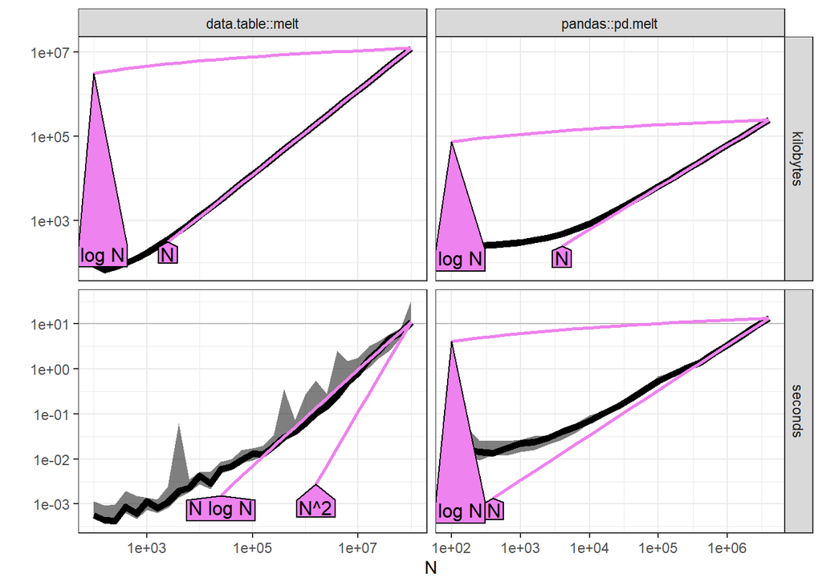

```r
ml.reshape.refs <- atime::references_best(ml.reshape.atime)
plot(ml.reshape.refs)
```

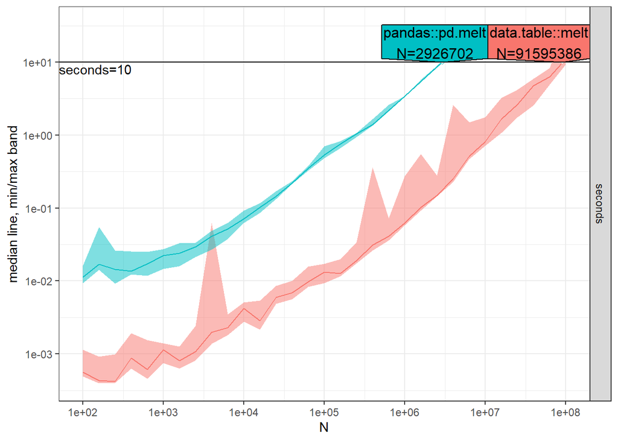

```r
ml.reshape.pred <- predict(ml.reshape.refs)
plot(ml.reshape.pred)
```

```r
ml.wide2long.pd <- plot(ml.reshape.pred)+
  theme(text=element_text(size=15))+
  ggtitle(sprintf("Reshaping from wide to long panda & data.table over %dreal numbers, N times", n.folds))+
  scale_x_log10("N = number of Mean,SD,Length to compute")+
  scale_y_log10("Computation time (seconds)
median line, min/max band
over 10 timings")+
  facet_null()+
  scale_fill_manual(values=ml.colors)+
  scale_color_manual(values=ml.colors)
```

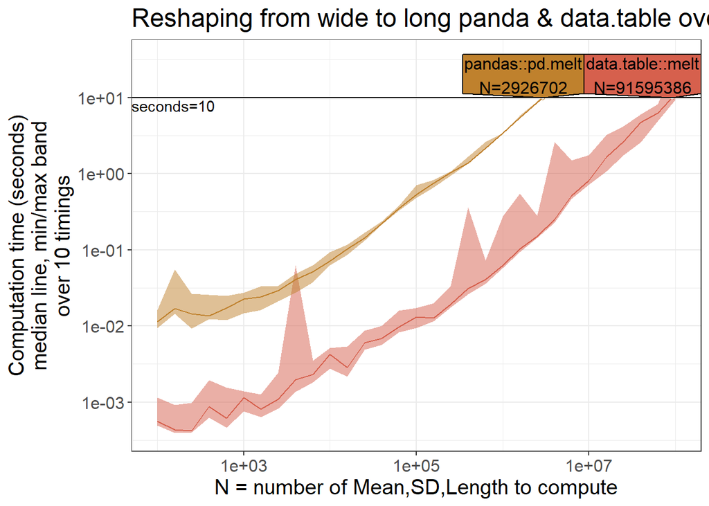

```r
plot(ml.wide2long.pd)
```

When converting data from wide to long format,As shown in the above plot, data.table’s melt() function efficiently gathers multiple columns into key-value pairs, allowing for easy transformation of wide data into a longer, more structured format.

## data.table::dcast() is faster

```r
ml.colors <- c(
  "data.table::dcast" = "#D6604D",
  "pandas::pivot_table" = "#BF812D"
)

n.folds <- 10
n.rows <- 100
seconds.limit <- 1

ml.long2wide.atime <- atime::atime(
  N=as.integer(10^seq(2, 7, by=0.2)),

  setup={
    df <- data.frame(
      id = rep(1:N, each = 2),
      category = rep(c("A", "B"), N),
      value = rnorm(2 * N)
      )
    },
  seconds.limit= seconds.limit,
  "data.table::dcast" = {
    data.table::dcast(data.table(df), id ~ category, value.var = "value")
  },
  "pandas::pivot_table" = {
    py_df <- reticulate::r_to_py(df)
    pd <- import("pandas")
    pd$pivot_table(py_df, values = "value", index = "id", columns = "category")
  }
  )
```

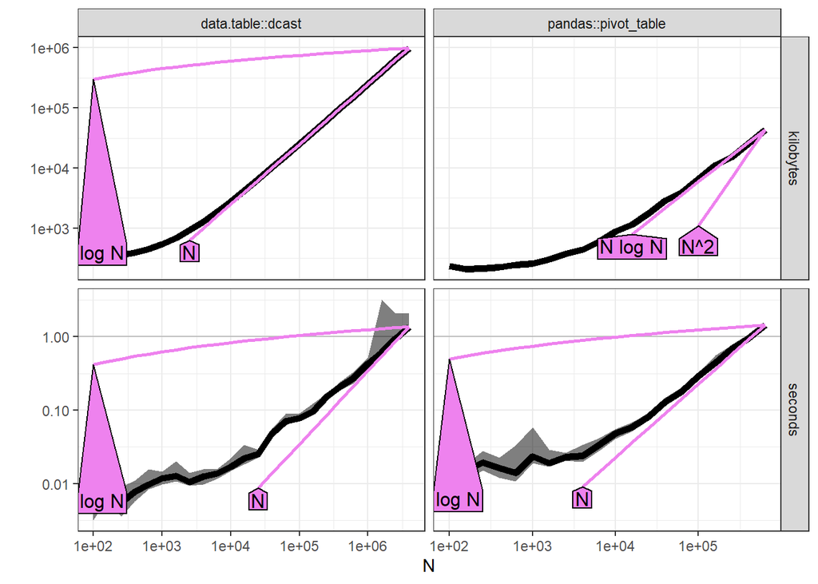

```r
ml.long2wide.refs <- atime::references_best(ml.long2wide.atime)
plot(ml.long2wide.refs)
```

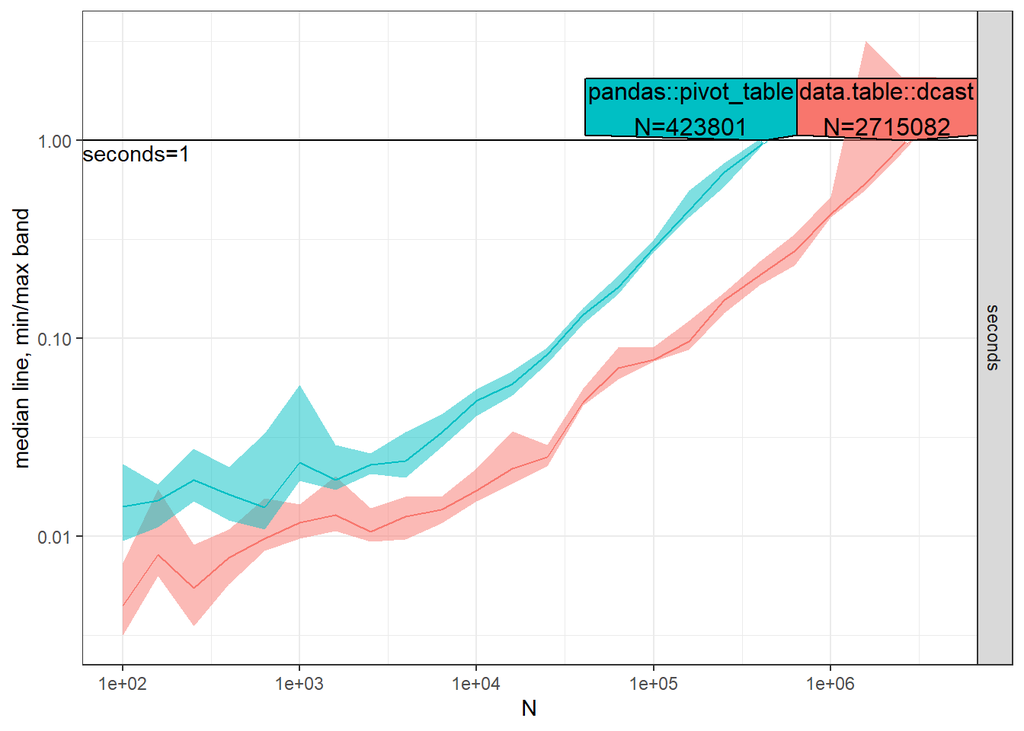

```r
ml.long2wide.pred <- predict(ml.long2wide.refs)
plot(ml.long2wide.pred)
```

```r
ml.long2wide <- plot(ml.long2wide.pred)+
  theme(text=element_text(size=15))+
  ggtitle(sprintf("Reshaping from long to wide over %dreal numbers, N times", n.folds))+
  scale_x_log10("N = number of Mean,SD,Length to compute")+
  scale_y_log10("Computation time (seconds)
median line, min/max band
over 10 timings")+
  facet_null()+
  scale_fill_manual(values=ml.colors)+
  scale_color_manual(values=ml.colors)
```

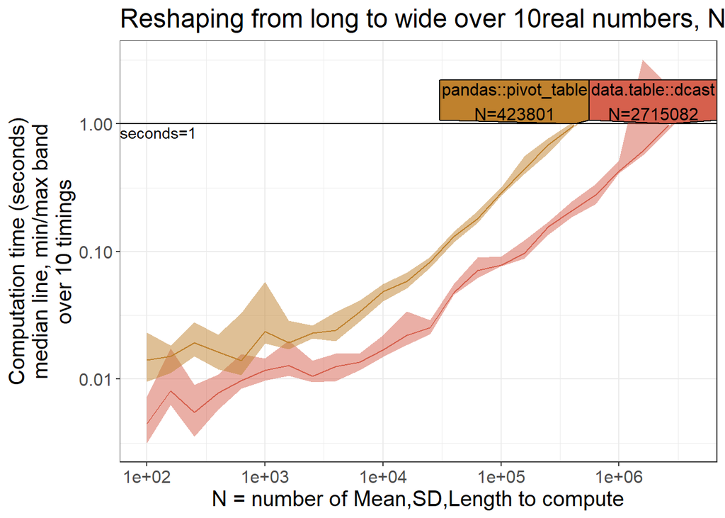

```r
plot(ml.long2wide)
```

On the other hand, when transforming data from long to wide format, data.table’s dcast() function proves to be more efficient.

Although data.table has advantages in terms of writing,reading and Rehaping, pandas in Python still provides a solid framework for data manipulation as seen in the plot.

# Conclusions

The choice between the two libraries ultimately depends on the specific requirements of your data manipulation tasks. It is recommended to consider the size of the dataset, the complexity of the operations, and personal preferences when making a decision.

# References:

[Reshape performance comparison](https://tdhock.github.io/blog/2024/reshape-performance/)

[compare-read-write](https://tdhock.github.io/blog/2023/compare-read-write/)

[data.table asymptotic timings](https://tdhock.github.io/blog/2023/dt-atime-figures/)

[atime package](https://github.com/tdhock/atime)